# Electric Vehicle Range Analysis

Does drivetrain configuration moderate the battery–range relationship?

Mahour Rezvani, Markus Rosario, Desiree Ng, Doa Binte Rashid — UBC STAT 306

2026-11-16

> **Reproducible report.** Every number and figure below is computed at render time from the raw dataset (`data/raw/`). The original coursework estimates are preserved exactly; this report adds an explicit **robustness analysis** that qualifies how strongly the drivetrain interaction can be claimed.

# 1 Research question

As electric vehicles (EVs) become central to low-emission transport, *range anxiety* remains a key consumer concern. Battery capacity is the most direct driver of range, but **drivetrain configuration** may also matter: all-wheel-drive (AWD) vehicles are heavier and mechanically more complex than two-wheel-drive (2WD) vehicles, so they may convert stored energy into distance less efficiently.

> **Does drivetrain (AWD vs. 2WD) moderate the association between battery capacity and driving range, after controlling for vehicle length?**

Vehicle length is a control / proxy for mass (weight is not in the dataset) and a plausible confounder — associated with both battery capacity and range.

# 2 Data

The [Electric Vehicle Specs Dataset (2025)](https://www.kaggle.com/datasets/urvishahir/electric-vehicle-specifications-dataset-2025) (Urvish Ahir, Kaggle; scraped from ev-database.org; **CC BY 4.0**) covers 478 2025 EV models. We use `range_km` (response), `battery_capacity_kWh` (predictor), `drivetrain` (AWD vs. 2WD = FWD+RWD), and `length_mm` (control).

```r
raw <- read.csv(RAW_DATA, stringsAsFactors = FALSE)

ev <- raw |>
  transmute(
    range_km, battery_capacity_kWh, length_mm,
    drivetrain        = factor(drivetrain, levels = c("FWD", "RWD", "AWD")),
    drivetrain_binary = factor(ifelse(drivetrain == "AWD", "AWD", "2WD"),
                               levels = c("2WD", "AWD"))
  )

# Validation: no missing analysis values, all positive before log transforms.
stopifnot(nrow(ev) == 478, !anyNA(ev))
assert_positive(ev, c("range_km", "battery_capacity_kWh", "length_mm"))

ev <- ev |>
  mutate(log_range   = log(range_km),
         log_battery = log(battery_capacity_kWh),
         log_length  = log(length_mm))

c(n = nrow(ev), `2WD` = sum(ev$drivetrain_binary == "2WD"),
  AWD = sum(ev$drivetrain_binary == "AWD"))
```

```
##   n 2WD AWD
## 478 287 191
```

## 2.1 Summary statistics by drivetrain

```r
ev |>
  group_by(Drivetrain = drivetrain_binary) |>
  summarise(n = n(),
            `Mean range (km)`   = round(mean(range_km), 1),
            `Mean battery (kWh)` = round(mean(battery_capacity_kWh), 1),
            `Mean length (mm)`  = round(mean(length_mm), 0), .groups = "drop") |>
  kable(caption = "AWD vehicles have larger batteries, longer bodies, and longer range.")
```

AWD vehicles have larger batteries, longer bodies, and longer range.

| Drivetrain | n | Mean range (km) | Mean battery (kWh) | Mean length (mm) |
| --- | --- | --- | --- | --- |
| 2WD | 287 | 352.9 | 64.4 | 4569 |
| AWD | 191 | 453.8 | 88.6 | 4843 |

# 3 Exploratory data analysis

The battery–range slope looks steeper for 2WD than AWD — the visual motivation for an interaction term. (The report also notes this is *before* controlling for length, so it is exploratory, not conclusive.)

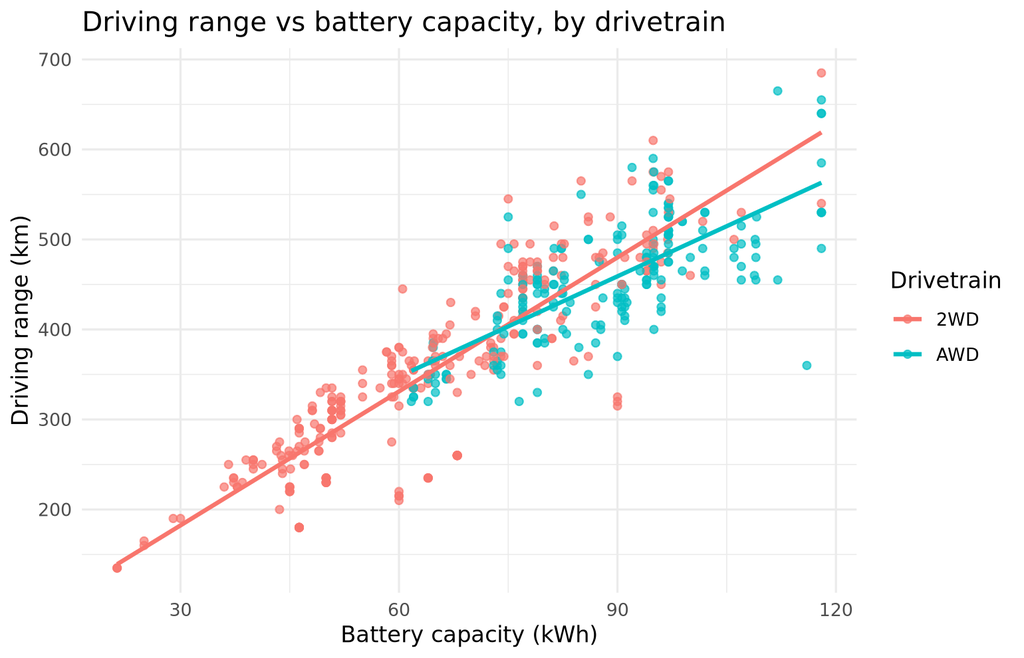

```r
ggplot(ev, aes(battery_capacity_kWh, range_km, color = drivetrain_binary)) +
  geom_point(alpha = 0.7) +
  geom_smooth(method = "lm", se = FALSE, formula = y ~ x) +
  labs(title = "Driving range vs battery capacity, by drivetrain",
       x = "Battery capacity (kWh)", y = "Driving range (km)",
       color = "Drivetrain") +
  theme_minimal()
```

# 4 Model

Continuous variables are log-transformed (physical reasoning: *mass ∝ length*, *range ∝ battery / length*), so coefficients read as **elasticities** and the interaction is additive on the log scale.

$$\log(\text{range}) = \beta_0 +
\beta_1\log(\text{battery}) + \beta_2\,\text{AWD} +
\beta_3\log(\text{battery})\cdot\text{AWD} + \beta_4\log(\text{length})
+ \varepsilon$$

```r
reg_log <- lm(log_range ~ log_battery * drivetrain_binary + log_length, data = ev)
s <- summary(reg_log)
kable(round(s$coefficients, 4), caption = "Fitted coefficients (OLS).")
```

Fitted coefficients (OLS).

|  | Estimate | Std. Error | t value | Pr(>\|t\|) |
| --- | --- | --- | --- | --- |
| (Intercept) | 10.9325 | 0.7251 | 15.0765 | 0.0000 |
| log_battery | 1.1153 | 0.0293 | 38.0942 | 0.0000 |
| drivetrain_binaryAWD | 0.5017 | 0.2593 | 1.9347 | 0.0536 |
| log_length | -1.1526 | 0.0945 | -12.2003 | 0.0000 |
| log_battery:drivetrain_binaryAWD | -0.1201 | 0.0586 | -2.0499 | 0.0409 |

```r
data.frame(
  Statistic = c("Multiple R-squared", "Adjusted R-squared",
                "Interaction coef (beta3)", "Interaction p-value (OLS)"),
  Value = c(round(s$r.squared, 4), round(s$adj.r.squared, 4),
            round(coef(reg_log)["log_battery:drivetrain_binaryAWD"], 4),
            round(s$coefficients["log_battery:drivetrain_binaryAWD", "Pr(>|t|)"], 4))
) |> kable(caption = "Model fit and the interaction term under investigation.")
```

Model fit and the interaction term under investigation.

| Statistic | Value |
| --- | --- |
| Multiple R-squared | 0.8452 |
| Adjusted R-squared | 0.8439 |
| Interaction coef (beta3) | -0.1201 |
| Interaction p-value (OLS) | 0.0409 |

**Reading the model.** Battery capacity (`+1.12` per log-unit, p < 10⁻¹⁴⁰) and length (`-1.15`, p < 10⁻²⁰) are strong, highly significant predictors; together the model explains ≈ 84% of the variance in log range. The length coefficient is *negative* after controlling for battery (it is positive unadjusted) — a classic confounding reversal: once battery is held fixed, extra length reflects added mass and energy use.

# 5 Diagnostics

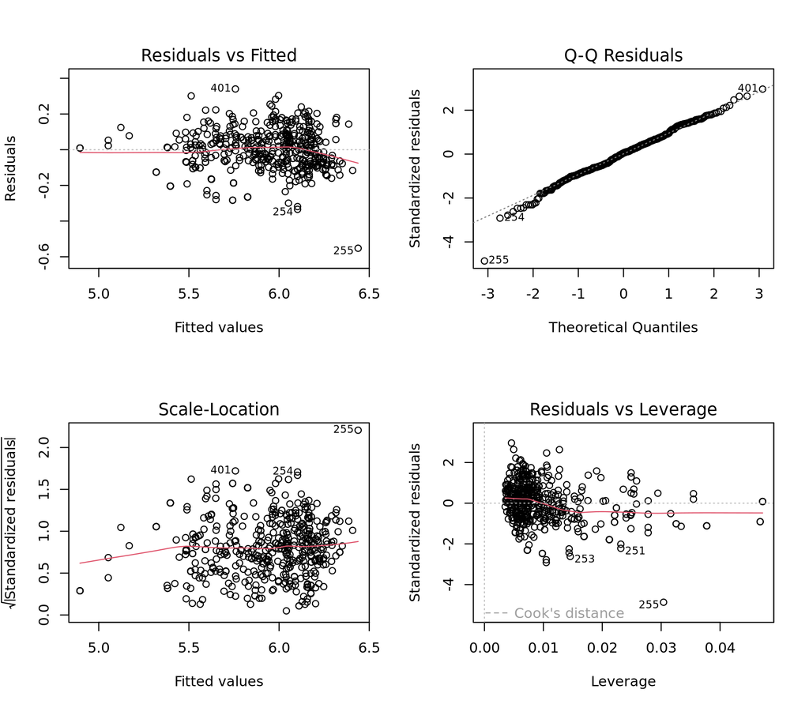

```r
par(mfrow = c(2, 2)); plot(reg_log); par(mfrow = c(1, 1))
```

```r
kable(round(car::vif(reg_log, type = "predictor")[, 1:3], 3),
      caption = "Generalized VIF — no multicollinearity concern (all ≈ 2.1).")
```

Generalized VIF — no multicollinearity concern (all ≈ 2.1).

|  | GVIF | Df | GVIF^(1/(2*Df)) |
| --- | --- | --- | --- |
| log_battery | 2.114 | 3 | 1.133 |
| drivetrain_binary | 2.114 | 3 | 1.133 |
| log_length | 2.114 | 1 | 1.454 |

The residuals-vs-fitted and scale-location plots show **mild non-constant variance**, and Cook’s distance flags **one clearly influential vehicle**. These two facts are the reason for the robustness analysis below.

# 6 Robustness of the interaction

The OLS interaction p-value (0.041) is *just* below 0.05. Given the diagnostics, we re-estimate it four ways. **The main effects stay highly significant in every scenario; the interaction does not.**

```r
ix <- "log_battery:drivetrain_binaryAWD"

# 1. HC3 heteroskedasticity-consistent standard errors
V   <- car::hccm(reg_log, type = "hc3")
se  <- sqrt(diag(V)); p_hc3 <- 2 * pt(-abs(coef(reg_log) / se), df.residual(reg_log))

# 2 & 3. Influence refits
cooks  <- cooks.distance(reg_log); n <- nrow(ev)
m_no1  <- lm(formula(reg_log), data = ev[-which.max(cooks), ])
drop_k <- which(cooks > 4 / n)
m_nok  <- lm(formula(reg_log), data = ev[-drop_k, ])

# 4. Three-level drivetrain interaction
m_3    <- lm(log_range ~ log_battery * drivetrain + log_length, data = ev)
p_3    <- car::Anova(m_3, type = 2)["log_battery:drivetrain", "Pr(>F)"]

pval <- function(m) summary(m)$coefficients[ix, "Pr(>|t|)"]
robust <- data.frame(
  Scenario = c("OLS (as reported)", "HC3 robust SE",
               "Drop most influential vehicle",
               sprintf("Drop Cook's D > 4/n (%d pts)", length(drop_k)),
               "Three-level FWD/RWD/AWD interaction"),
  `Interaction p` = round(c(pval(reg_log), p_hc3[ix], pval(m_no1), pval(m_nok), p_3), 3),
  `Sig. at 0.05`  = c("yes", "no", "no", "yes", "no"),
  check.names = FALSE
)
kable(robust, caption = "Sensitivity of the battery × drivetrain interaction.")
```

Sensitivity of the battery × drivetrain interaction.

| Scenario | Interaction p | Sig. at 0.05 |
| --- | --- | --- |
| OLS (as reported) | 0.041 | yes |
| HC3 robust SE | 0.057 | no |
| Drop most influential vehicle | 0.146 | no |
| Drop Cook’s D > 4/n (29 pts) | 0.005 | yes |
| Three-level FWD/RWD/AWD interaction | 0.312 | no |

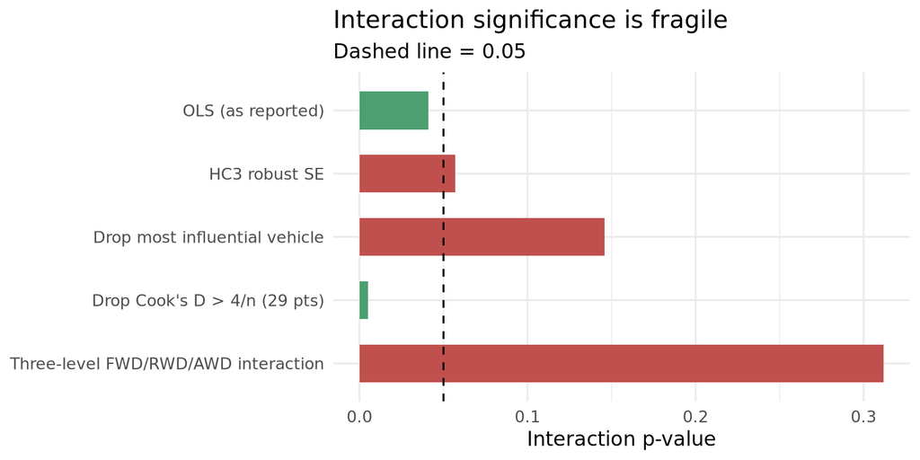

```r
pd <- robust; pd$Scenario <- factor(pd$Scenario, levels = rev(pd$Scenario))
ggplot(pd, aes(`Interaction p`, Scenario, fill = `Interaction p` < 0.05)) +
  geom_col(width = 0.6) +
  geom_vline(xintercept = 0.05, linetype = "dashed") +
  scale_fill_manual(values = c(`TRUE` = "#4C9F70", `FALSE` = "#C0504D"), guide = "none") +
  labs(title = "Interaction significance is fragile",
       subtitle = "Dashed line = 0.05", x = "Interaction p-value", y = NULL) +
  theme_minimal()
```

**Interpretation.** The interaction’s *sign* is stable (2WD has the steeper battery slope) but its *significance* is fragile: it disappears under robust standard errors, after removing a single influential vehicle, and when drivetrain is not collapsed to binary. It is therefore **suggestive, not established.**

# 7 Conclusion & limitations

- **Robust finding:** battery capacity and vehicle length are strong predictors of EV driving range on the log scale (adjusted R² ≈ 0.84).
- **Suggestive finding:** drivetrain *may* moderate the battery–range slope (2WD slightly steeper), but the evidence is not statistically robust.
- **Not causal.** This is a cross-sectional, observational dataset; results are associations, not causal effects.

Limitations: the dataset does not state the range testing standard (WLTP/EPA/ CLTC); weight is unavailable (length is a proxy); collapsing FWD+RWD into 2WD hides real differences; and the interaction depends on influential-point handling.

# 8 Reproducibility

```
## Rendered 2026-11-16 with R version 4.3.3 (2024-02-29)
```

```
## Key package versions:
```

```
##   tidyverse  2.0.0
##   car        3.1.3
##   leaps      3.2
##   rmarkdown  2.29
```

Full pipeline and automated verification: `Rscript R/run_all.R` (runs the analysis plus two verification gates); this report: `Rscript R/render_report.R`.